# GROUP 4 Markdown report

Group 4

23/09/2022

## Introduction

This report includes the work of Group 4.

### Describing the dataset

We were provided with a datset collected with funding from the National Institute of Diabetes and Digestive and Kidney Diseases (NIDDK). The dataset includes females from 21 years of age, and of Pima Indian heritage, with at least 5 years of followup in a longitudinal study of diabetes.

We were given specific assignments regarding reading, tidying, exploring and analyzing the provided dataset. The report is organized chronologically as the assigments were given.

### Loading necessary packages for the given tasks

```r
library(tidyverse)
library(here)
```

```r
library(ggplot2)
```

## Day 5

The primary object is to read the dataset into R software and tidy the data using the tidyverse package

### Reading the data into R program

```r
  Group_4_data <- read_delim(here("data", "exam_nontidy - copy.txt"), delim = "\t")
```

### Seperating columns that contain multiple variables in column cells

```r
##Separate columns----
Group_4_data <-
  Group_4_data %>%
  separate(col = `pregnancy_num-age`,
           into = c("pregnancy_num", "age"),
           sep = "-")

##separate hospital and subject
Group_4_data <-
  Group_4_data %>%
  separate(col = subject,
           into = c("hospital", "subject"),
           sep = "-")
```

### Removing duplicate values from columns

```r
## Removing duplicates----
Group_4_data <-
  Group_4_data %>%
  distinct()
```

### Changing column names

```r
##Change column names that contain spaces or start with numbers (or characters?)----
Group_4_data <-
  Group_4_data %>%
  rename(id = `subject`,
         insulin_microiu_ml = `insulin microiu ml`,
         diabetes_5y = `5y diabetes`,
         measured_variable = `measured variable`,
         value = `.value`
  )
```

### Applying pivot to create new columns for distinct measurement types

```r
## Pivoting columns with values from various measurements----
Group_4_data <- Group_4_data %>%
  pivot_wider(names_from = "measured_variable",
              values_from = "value")
```

## Day 6

The primary object is to further tidy the data, adjust it in preparation for analysis, and explore the data after making the necessary adjustments.

### Removing variables that are not necessary for downstream analysis

```r
#Working with Tidyverse to tidy, adjust, and explore the data set

## Remove  columns from the dataframe: choleste, sibling ----
Group_4_data <-
  Group_4_data %>%
  select(-c(sibling, choleste))
```

### Adjusting values listed as categorical to numerical

```r
## Change variable type ----
Group_4_data <-
  Group_4_data %>%
  mutate(pregnancy_num = as.numeric(pregnancy_num),
         age = as.numeric(age),
         id = as.numeric(id))
```

```r
## Create set of columns for: glucose_mg_dl>120, insulin in units pmol/L ----
## diabetes_5y as 0/1, multiplication of age and pregnancy_num
Group_4_data <-
  Group_4_data %>%
  mutate(glucose_mg_dl_classifier = if_else(glucose_mg_dl >= 120, "High", "Low")) %>%
  mutate(insulin_microiu_pmol_l = insulin_microiu_ml*6.945) %>%
  mutate(diabetes_5y_classifier = if_else(diabetes_5y == "pos", "1","0")) %>%
  mutate(multiply_age_pregnancy = age*pregnancy_num) %>%
  select(id,hospital,age,everything()) %>%
  arrange(id)
```

### Joining an additional dataset containing information about antibody measurements to the main dataset

```r
##Read and join additional dataset to your main dataset----
Joining_data <- read_delim(here("data", "exam_joindata - copy.txt"), delim = "\t")
##Join datasets----
Group_4_joined_data <-
  Group_4_data %>%
  left_join(Joining_data, by = "id")
```

### Exploring the dataset after the making the above changes

```r
##Explore data again after adjustments ----
summary(Group_4_joined_data)
```

```
##        id          hospital              age        pregnancy_num
##  Min.   :  1.0   Length:768         Min.   :21.00   Min.   : 0.000
##  1st Qu.:192.8   Class :character   1st Qu.:24.00   1st Qu.: 1.000
##  Median :384.5   Mode  :character   Median :29.00   Median : 3.000
##  Mean   :384.5                      Mean   :33.24   Mean   : 3.845
##  3rd Qu.:576.2                      3rd Qu.:41.00   3rd Qu.: 6.000
##  Max.   :768.0                      Max.   :81.00   Max.   :17.000
##
##    triceps_mm    insulin_microiu_ml      bmi           pedigree
##  Min.   : 7.00   Min.   : 14.00     Min.   :18.20   Min.   :0.0780
##  1st Qu.:22.00   1st Qu.: 76.25     1st Qu.:27.50   1st Qu.:0.2437
##  Median :29.00   Median :125.00     Median :32.30   Median :0.3725
##  Mean   :29.15   Mean   :155.55     Mean   :32.46   Mean   :0.4719
##  3rd Qu.:36.00   3rd Qu.:190.00     3rd Qu.:36.60   3rd Qu.:0.6262
##  Max.   :99.00   Max.   :846.00     Max.   :67.10   Max.   :2.4200
##  NA's   :227     NA's   :374        NA's   :11
##  diabetes_5y        glucose_mg_dl     dbp_mm_hg      glucose_mg_dl_classifier
##  Length:768         Min.   : 44.0   Min.   : 24.00   Length:768
##  Class :character   1st Qu.: 99.0   1st Qu.: 64.00   Class :character
##  Mode  :character   Median :117.0   Median : 72.00   Mode  :character
##                     Mean   :121.7   Mean   : 72.41
##                     3rd Qu.:141.0   3rd Qu.: 80.00
##                     Max.   :199.0   Max.   :122.00
##                     NA's   :5       NA's   :35
##  insulin_microiu_pmol_l diabetes_5y_classifier multiply_age_pregnancy
##  Min.   :  97.23        Length:768             Min.   :  0.0
##  1st Qu.: 529.56        Class :character       1st Qu.: 26.0
##  Median : 868.12        Mode  :character       Median : 83.0
##  Mean   :1080.28                               Mean   :149.4
##  3rd Qu.:1319.55                               3rd Qu.:246.5
##  Max.   :5875.47                               Max.   :799.0
##  NA's   :374
##     antibody
##  Min.   : 20.08
##  1st Qu.: 62.99
##  Median :101.41
##  Mean   :107.54
##  3rd Qu.:151.90
##  Max.   :199.39
##  NA's   :568
```

```r
glimpse(Group_4_joined_data)
```

```
## Rows: 768
## Columns: 16
## $ id                       <dbl> 1, 2, 3, 4, 5, 6, 7, 8, 9, 10, 11, 12, 13, 14…
## $ hospital                 <chr> "Hosp1", "Hosp1", "Hosp1", "Hosp1", "Hosp1", …
## $ age                      <dbl> 50, 31, 32, 21, 33, 30, 26, 29, 53, 54, 30, 3…
## $ pregnancy_num            <dbl> 6, 1, 8, 1, 0, 5, 3, 10, 2, 8, 4, 10, 10, 1, …
## $ triceps_mm               <dbl> 35, 29, NA, 23, 35, NA, 32, NA, 45, NA, NA, N…
## $ insulin_microiu_ml       <dbl> NA, NA, NA, 94, 168, NA, 88, NA, 543, NA, NA,…
## $ bmi                      <dbl> 33.6, 26.6, 23.3, 28.1, 43.1, 25.6, 31.0, 35.…
## $ pedigree                 <dbl> 0.627, 0.351, 0.672, 0.167, 2.288, 0.201, 0.2…
## $ diabetes_5y              <chr> "pos", "neg", "pos", "neg", "pos", "neg", "po…
## $ glucose_mg_dl            <dbl> 148, 85, 183, 89, 137, 116, 78, 115, 197, 125…
## $ dbp_mm_hg                <dbl> 72, 66, 64, 66, 40, 74, 50, NA, 70, 96, 92, 7…
## $ glucose_mg_dl_classifier <chr> "High", "Low", "High", "Low", "High", "Low", …
## $ insulin_microiu_pmol_l   <dbl> NA, NA, NA, 652.830, 1166.760, NA, 611.160, N…
## $ diabetes_5y_classifier   <chr> "1", "0", "1", "0", "1", "0", "1", "0", "1", …
## $ multiply_age_pregnancy   <dbl> 300, 31, 256, 21, 0, 150, 78, 290, 106, 432, …
## $ antibody                 <dbl> NA, NA, NA, NA, NA, NA, 118.54270, NA, NA, 15…
```

```r
skimr::skim(Group_4_joined_data)
```

Data summary

| Name | Group_4_joined_data |
| --- | --- |
| Number of rows | 768 |
| Number of columns | 16 |
| _______________________ |  |
| Column type frequency: |  |
| character | 4 |
| numeric | 12 |
| ________________________ |  |
| Group variables | None |

**Variable type: character**

| skim_variable | n_missing | complete_rate | min | max | empty | n_unique | whitespace |
| --- | --- | --- | --- | --- | --- | --- | --- |
| hospital | 0 | 1.00 | 5 | 5 | 0 | 3 | 0 |
| diabetes_5y | 0 | 1.00 | 3 | 3 | 0 | 2 | 0 |
| glucose_mg_dl_classifier | 5 | 0.99 | 3 | 4 | 0 | 2 | 0 |
| diabetes_5y_classifier | 0 | 1.00 | 1 | 1 | 0 | 2 | 0 |

**Variable type: numeric**

| skim_variable | n_missing | complete_rate | mean | sd | p0 | p25 | p50 | p75 | p100 | hist |
| --- | --- | --- | --- | --- | --- | --- | --- | --- | --- | --- |
| id | 0 | 1.00 | 384.50 | 221.85 | 1.00 | 192.75 | 384.50 | 576.25 | 768.00 | ▇▇▇▇▇ |
| age | 0 | 1.00 | 33.24 | 11.76 | 21.00 | 24.00 | 29.00 | 41.00 | 81.00 | ▇▃▁▁▁ |
| pregnancy_num | 0 | 1.00 | 3.85 | 3.37 | 0.00 | 1.00 | 3.00 | 6.00 | 17.00 | ▇▃▂▁▁ |
| triceps_mm | 227 | 0.70 | 29.15 | 10.48 | 7.00 | 22.00 | 29.00 | 36.00 | 99.00 | ▆▇▁▁▁ |
| insulin_microiu_ml | 374 | 0.51 | 155.55 | 118.78 | 14.00 | 76.25 | 125.00 | 190.00 | 846.00 | ▇▂▁▁▁ |
| bmi | 11 | 0.99 | 32.46 | 6.92 | 18.20 | 27.50 | 32.30 | 36.60 | 67.10 | ▅▇▃▁▁ |
| pedigree | 0 | 1.00 | 0.47 | 0.33 | 0.08 | 0.24 | 0.37 | 0.63 | 2.42 | ▇▃▁▁▁ |
| glucose_mg_dl | 5 | 0.99 | 121.69 | 30.54 | 44.00 | 99.00 | 117.00 | 141.00 | 199.00 | ▁▇▇▃▂ |
| dbp_mm_hg | 35 | 0.95 | 72.41 | 12.38 | 24.00 | 64.00 | 72.00 | 80.00 | 122.00 | ▁▃▇▂▁ |
| insulin_microiu_pmol_l | 374 | 0.51 | 1080.28 | 824.90 | 97.23 | 529.56 | 868.12 | 1319.55 | 5875.47 | ▇▂▁▁▁ |
| multiply_age_pregnancy | 0 | 1.00 | 149.36 | 160.89 | 0.00 | 26.00 | 83.00 | 246.50 | 799.00 | ▇▂▁▁▁ |
| antibody | 568 | 0.26 | 107.54 | 51.88 | 20.08 | 62.99 | 101.41 | 151.90 | 199.39 | ▆▇▆▆▆ |

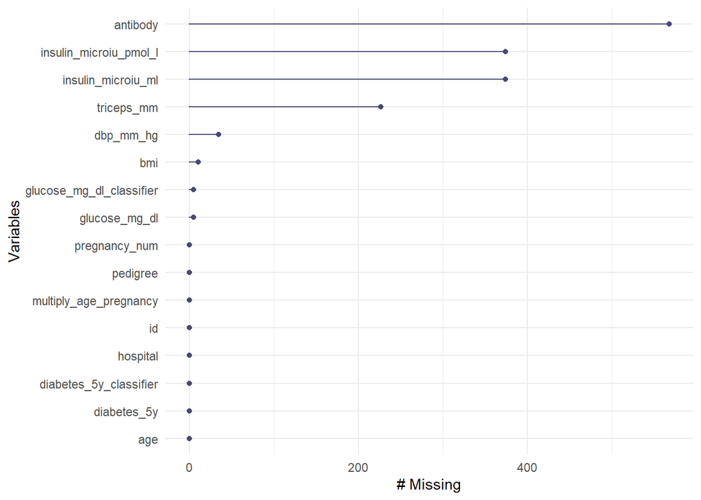

```r
naniar::gg_miss_var(Group_4_joined_data)
```

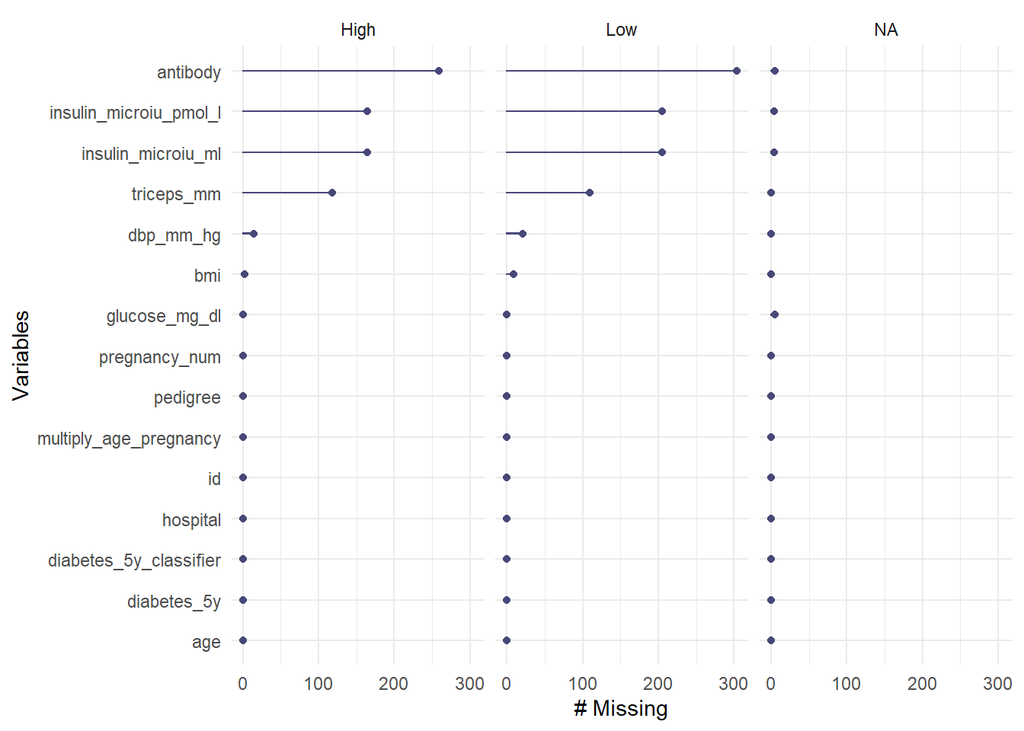

```r
naniar::gg_miss_var(Group_4_joined_data, facet = glucose_mg_dl_classifier)
```

### Stratifying data by a categorical column

```r
##Stratify data by BMI and report: min,max,mean,sd----
Group_4_joined_data %>%
  group_by(glucose_mg_dl_classifier) %>%
  summarise(max(bmi, na.rm = T), min(bmi, na.rm = T), mean(bmi, na.rm = T),
            sd(bmi, na.rm = T))
```

```
## # A tibble: 3 × 5
##   glucose_mg_dl_classifier `max(bmi, na.rm = T)` min(bmi, na.r…¹ mean(…² sd(bm…³
##   <chr>                                    <dbl>           <dbl>   <dbl>   <dbl>
## 1 High                                      67.1            19.6    34.0    6.90
## 2 Low                                       55              18.2    31.0    6.66
## 3 <NA>                                      41              24.7    32.9    7.03
## # … with abbreviated variable names ¹`min(bmi, na.rm = T)`,
## #   ²`mean(bmi, na.rm = T)`, ³`sd(bmi, na.rm = T)`
```

### Stratifying data by a categorical column and reporting for a defined set of observations

```r
##Stratify data by specific categorical column: min,max,mean,sd----

Group_4_joined_data %>%
  group_by(glucose_mg_dl_classifier) %>%
  filter(diabetes_5y == "pos") %>%
  filter(hospital == "Hosp1") %>%
  filter(pregnancy_num > 2) %>%
  filter(glucose_mg_dl < 120 & glucose_mg_dl > 60) %>%
  summarise(max(dbp_mm_hg, na.rm = T), min(dbp_mm_hg, na.rm = T), mean(dbp_mm_hg, na.rm = T),
            sd(dbp_mm_hg, na.rm = T))
```

```
## # A tibble: 1 × 5
##   glucose_mg_dl_classifier `max(dbp_mm_hg, na.rm = T)` min(dbp…¹ mean(…² sd(db…³
##   <chr>                                          <dbl>     <dbl>   <dbl>   <dbl>
## 1 Low                                               80        50    69.1    9.86
## # … with abbreviated variable names ¹`min(dbp_mm_hg, na.rm = T)`,
## #   ²`mean(dbp_mm_hg, na.rm = T)`, ³`sd(dbp_mm_hg, na.rm = T)`
```

## Day 7

The primary objective is to use the ggplot2 packages to create plots that can be used to answer questions about correlations within the dataset

### Investigating associations between glucose levels and insulin

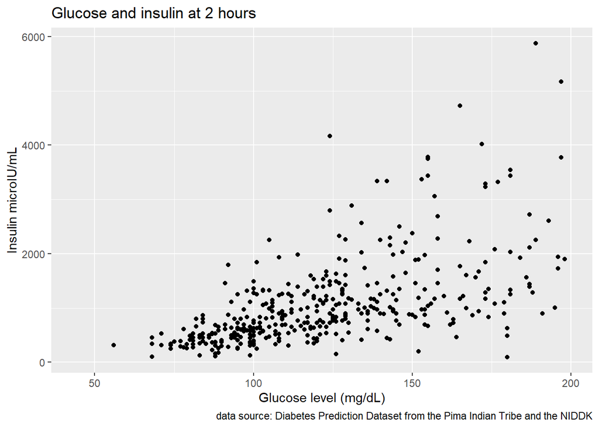

```r
##Glucose and insulin----
##Does the level of glucose and insulin depend on each other?
Glucose_insulin_plot <-
  ggplot(Group_4_joined_data) +
  aes(x = glucose_mg_dl,
      y = insulin_microiu_pmol_l) +
  geom_point() +
  xlab("Glucose level (mg/dL)") +
  ylab("Insulin microIU/mL") +
  labs(title = "Glucose and insulin at 2 hours",
       caption = "data source: Diabetes Prediction Dataset from the Pima Indian Tribe and the NIDDK")
Glucose_insulin_plot
```

### Investigating associations between glucose levels and insulin, when stratifying by diabetes outcome

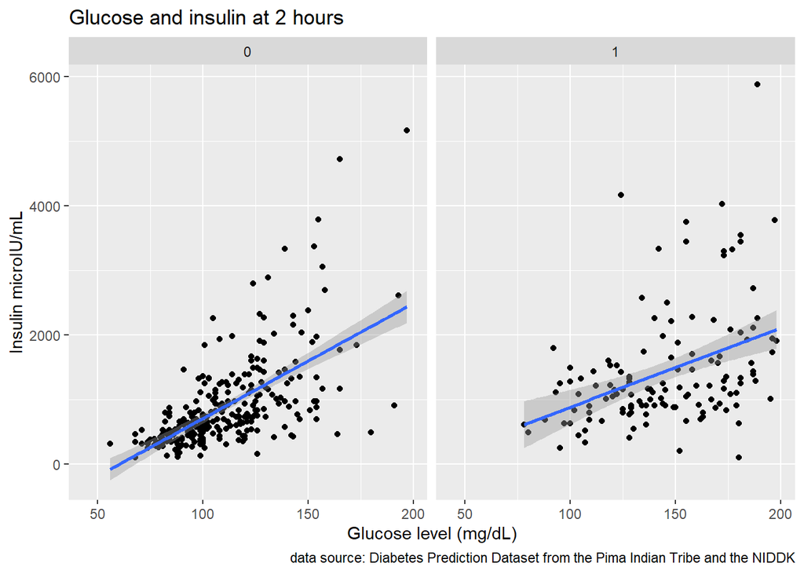

```r
##Stratify diabetes and check Glucose and insulin----
##Does the level of glucose and insulin depend on each other, when stratifying by outcome (diabetes_5y)?
Glucose_insulin_plot_stratified <-
  ggplot(Group_4_joined_data) +
  aes(x = glucose_mg_dl,
      y = insulin_microiu_pmol_l) +
  geom_point() +
  facet_wrap(facets = vars(diabetes_5y_classifier)) +
  geom_smooth(method = "lm") +
  xlab("Glucose level (mg/dL)") +
  ylab("Insulin microIU/mL") +
  labs(title = "Glucose and insulin at 2 hours",
       caption = "data source: Diabetes Prediction Dataset from the Pima Indian Tribe and the NIDDK")
Glucose_insulin_plot_stratified
```

#### Commenting on plot between glucose levels and insulin, after stratifying by diabetes outcome

As without the stratification, there is a tendency to higher insulin with higher glucose. However, there are fewer observations for those with diabetes vs those without, which makes the results for those with diabetes less reliable.

### Investigating associations between glucose levels and blood pressure

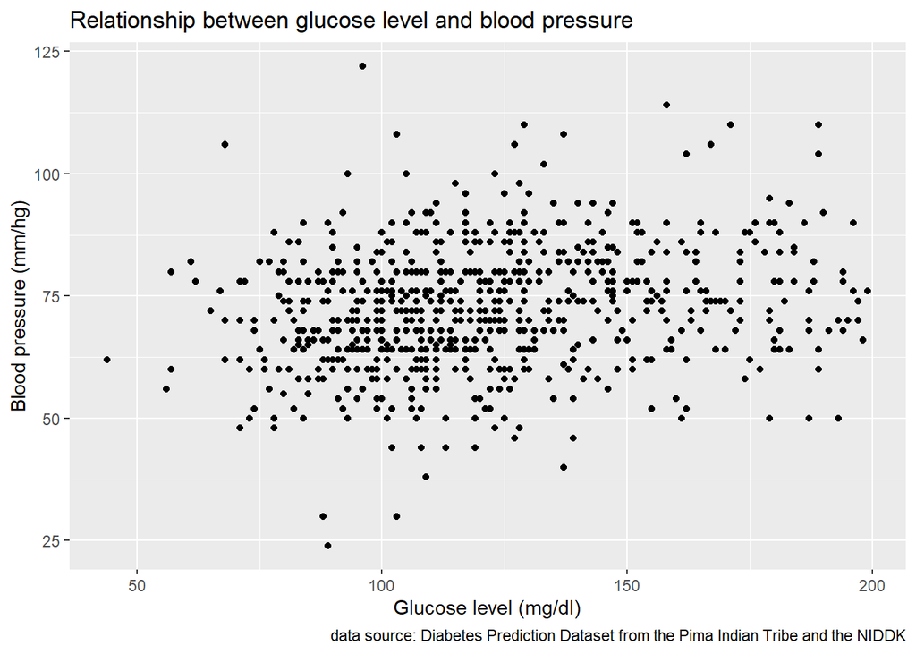

```r
## Glucose and blood pressure----
## Does the level of glucose and blood pressure depend on each other?
glucose_bp <-
  ggplot(Group_4_joined_data) +
  aes(x = glucose_mg_dl,
      y = dbp_mm_hg) +
  geom_point() +
  xlab("Glucose level (mg/dl)") +
  ylab("Blood pressure (mm/hg)") +
  labs(title = "Relationship between glucose level and blood pressure",
       caption = "data source: Diabetes Prediction Dataset from the Pima Indian Tribe and the NIDDK")
glucose_bp
```

#### Commenting on plot between glucose levels and blood pressure

Visually, it does not look like there is a relationship between level of glucose and blood pressure

### Investigating associations between bmi and subcutaneous fat

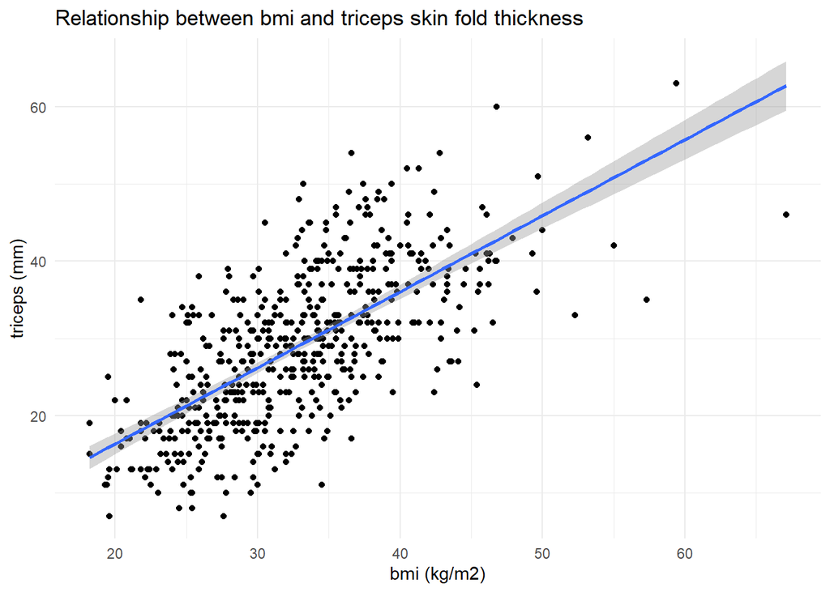

```r
##BMI and triceps_mm values association----
bmi_triceps_plot <- Group_4_joined_data %>%
  filter(triceps_mm < 90) %>%
  ggplot(aes(x = bmi,
             y = triceps_mm)) +
  geom_point() +
  geom_smooth(method = lm,
              se = T) +
  labs(x = "bmi (kg/m2)",
       y = "triceps (mm)",
       title = "Relationship between bmi and triceps skin fold thickness") +
  theme_minimal()
bmi_triceps_plot
```

This plot demonstrates that there appears to be a correlation between BMI and subcutaneous fat, as measured by triceps skin fold thickness.

### Investigating whether blood pressure is different when comparing different BMI ranges

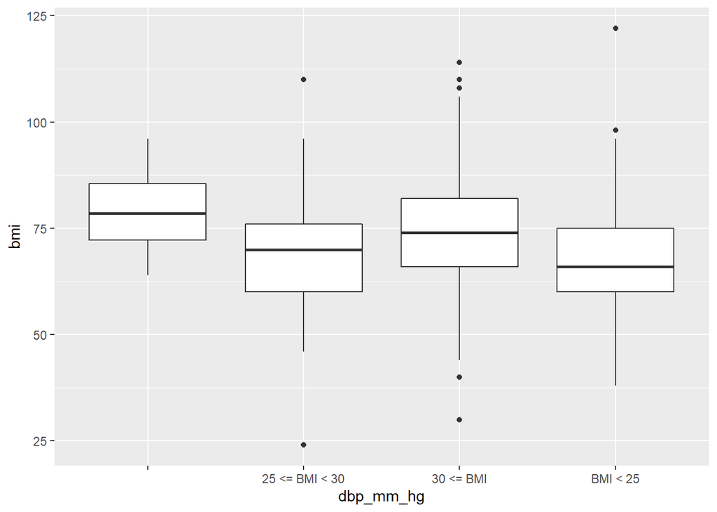

```r
##Distribution of blood pressure between BMI----
##Is the blood pressure distribution different between these BMI categories?
Bloodpressure_BMI <- vector(mode ="character", length(Group_4_joined_data$bmi))
Bloodpressure_BMI[Group_4_joined_data$bmi<25] <- "BMI < 25"
Bloodpressure_BMI[Group_4_joined_data$bmi >= 25 &
                    Group_4_joined_data$bmi < 30] <- "25 <= BMI < 30"
Bloodpressure_BMI[Group_4_joined_data$bmi>=30] <- "30 <= BMI"

Group_4_joined_data$Bloodpressure_BMI <- Bloodpressure_BMI

ggplot(Group_4_joined_data) +
  aes(x = Bloodpressure_BMI,
      y = dbp_mm_hg
  ) +
  geom_boxplot() +
ylab("bmi") +
  xlab("dbp_mm_hg")
```

#### Commenting on plot between blood pressure within different BMI categories

Blood pressure is progressively higher in the different BMI categories, the lowest blood pressure in the BMI<25 group, followed by slightly higher in 25 <= BMI < 30, and the highest in BMI <= 30.

### Day 8

The primary analysis task is to classify in each participant whether diabetes developed within 5 years of data collection.In this final section, we have explored several possible correlations within the dataset.

### Does the outcome depend on hospital? Explored by performing an anova test.

**ANOVA**

```r
  Group_4_joined_data %>%
  aov(diabetes_5y_classifier~hospital, data = .) %>%
  broom::tidy()
```

```
## # A tibble: 2 × 6
##   term         df   sumsq meansq statistic p.value
##   <chr>     <dbl>   <dbl>  <dbl>     <dbl>   <dbl>
## 1 hospital      2   0.551  0.275      1.21   0.298
## 2 Residuals   765 174.     0.227     NA     NA
```

*The anova test yields a p-value of 0.298, which indicates that the outcome does not depend on hospital.*

### Does the outcome depend on pedigree? Explored by performing a t-test.

**T-test**

```r
Group_4_joined_data %>%
  t.test(pedigree~diabetes_5y_classifier, data = .) %>%
  broom::tidy()
```

```
## # A tibble: 1 × 10
##   estim…¹ estim…² estim…³ stati…⁴ p.value param…⁵ conf.…⁶ conf.…⁷ method alter…⁸
##     <dbl>   <dbl>   <dbl>   <dbl>   <dbl>   <dbl>   <dbl>   <dbl> <chr>  <chr>
## 1  -0.121   0.430   0.550   -4.58 6.10e-6    455.  -0.173 -0.0689 Welch… two.si…
## # … with abbreviated variable names ¹estimate, ²estimate1, ³estimate2,
## #   ⁴statistic, ⁵parameter, ⁶conf.low, ⁷conf.high, ⁸alternative
```

### Does the outcome depend on BMI? Explored in a t-test.

**T-test**

```r
Group_4_joined_data %>%
  t.test(bmi~diabetes_5y_classifier, data = .) %>%
  broom::tidy()
```

```
## # A tibble: 1 × 10
##   estimate estimate1 estimate2 statistic  p.value param…¹ conf.…² conf.…³ method
##      <dbl>     <dbl>     <dbl>     <dbl>    <dbl>   <dbl>   <dbl>   <dbl> <chr>
## 1    -4.55      30.9      35.4     -9.06 2.48e-18    540.   -5.53   -3.56 Welch…
## # … with 1 more variable: alternative <chr>, and abbreviated variable names
## #   ¹parameter, ²conf.low, ³conf.high
```

*The p-value is 2.48e-18, so yes, the outcome depends on bmi. With higher bmi, it is more likely to develop diabetes within 5 years.*

### Does the outcome depend on glucose_mg_dl? Explored in a t-test.

**T-test**

```r
Group_4_joined_data %>%
  t.test(glucose_mg_dl~diabetes_5y_classifier, data = .) %>%
  broom::tidy()
```

```
## # A tibble: 1 × 10
##   estimate estimate1 estimate2 statistic  p.value param…¹ conf.…² conf.…³ method
##      <dbl>     <dbl>     <dbl>     <dbl>    <dbl>   <dbl>   <dbl>   <dbl> <chr>
## 1    -31.7      111.      142.     -14.9 2.84e-41    466.   -35.9   -27.5 Welch…
## # … with 1 more variable: alternative <chr>, and abbreviated variable names
## #   ¹parameter, ²conf.low, ³conf.high
```

*The p-value is 2.84e-41 indicating that the outcome does in fact depend on glucose_mg_dl.*